# Cellulose addition experiment

## sample summary

Soil samples were collected along a treeline in northwest Alaska, in the western brooks range near the agashashok river. Roughly 60 5cm diameter cores were take between 10-15 cm (only organic horizon was taken).The soil was homogenized and frozen for shipment to Toledo Ohio. In Toledo soils were thawed, further homogenized and kept at 4 °C for roughly a week. Soil subsamples were placed in mesocosms and cellobiose, cellotetraose, cellulose-20, cellulose-90, and coloidal cellulose were added in equal amounts being careful to keep soil moisture constant. Soils were then incubated at -6, -2, 2 , 6, 10 °C for several months. During the incubation respiration was measured and at the end of the incubation soils were destructively harvested for K2SO4/FUM and MPLEx extractions, and sub samples were used to measure enzyme activity. Below is the data.

## Respiration results

**click to open**

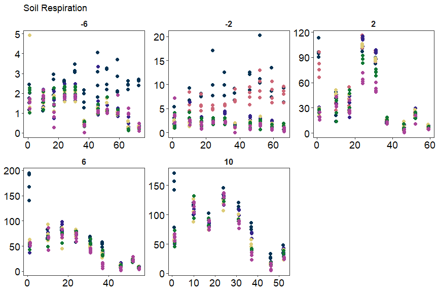

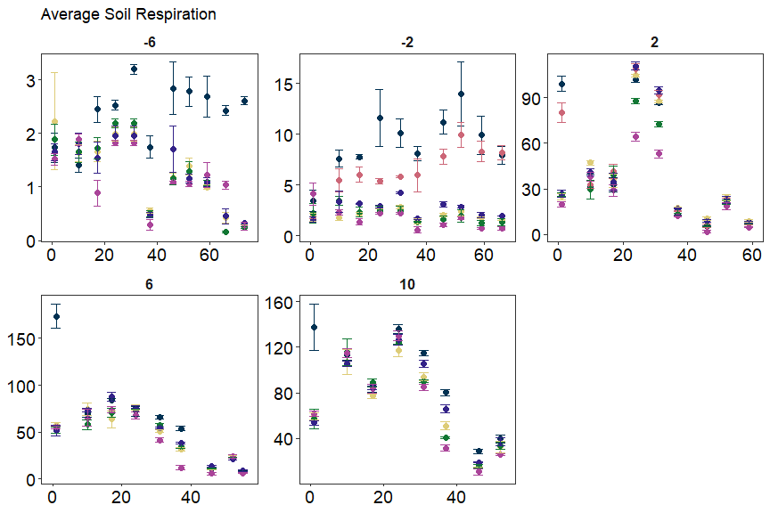

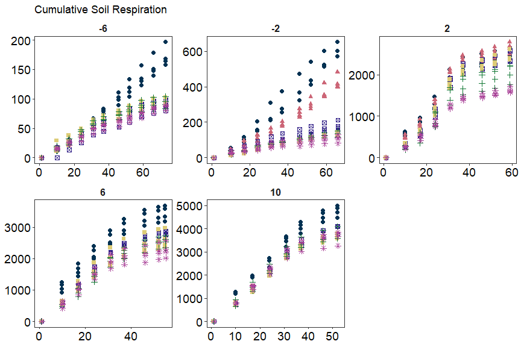

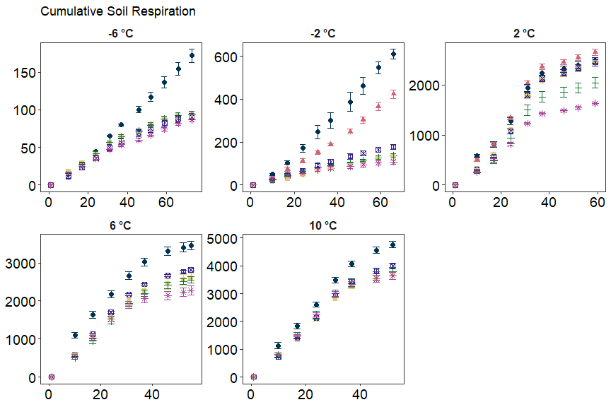

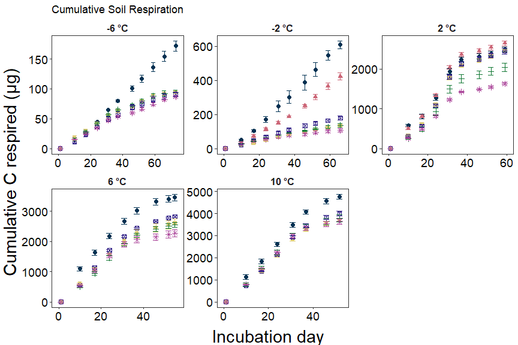

## Soil Nutrients

**click to open**

Soil K2SO4 extracts were utilized to measure ammonium, Nitrate, Total free primary amines, phosphate, Total reducing sugars. Below is the concentration data.

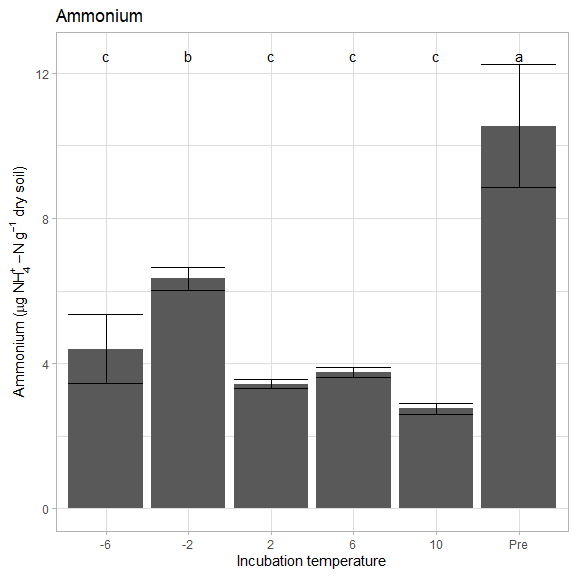

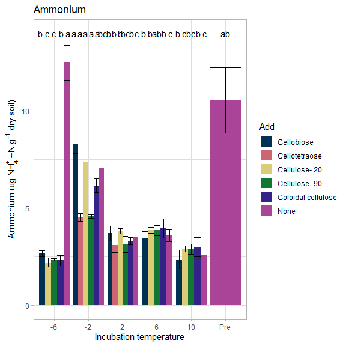

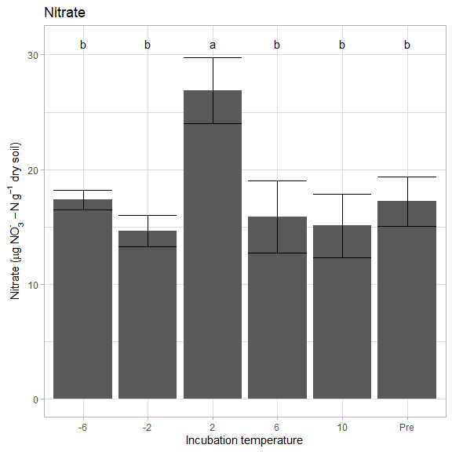

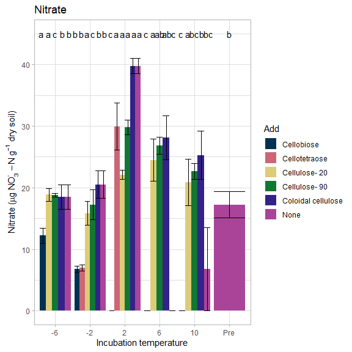

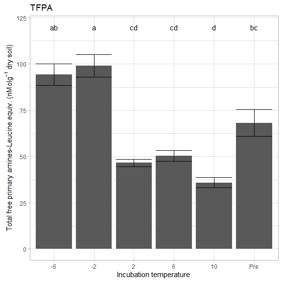

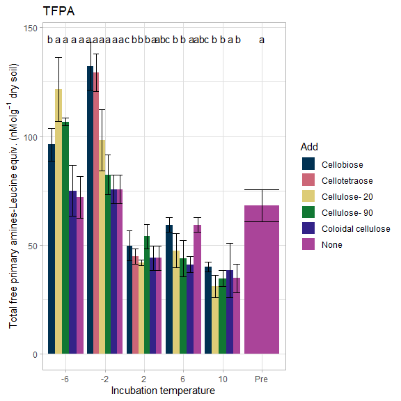

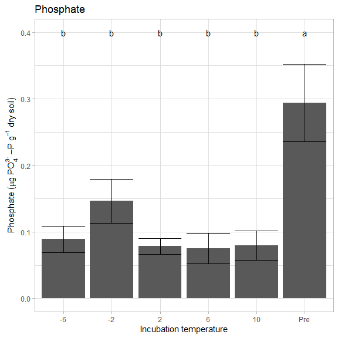

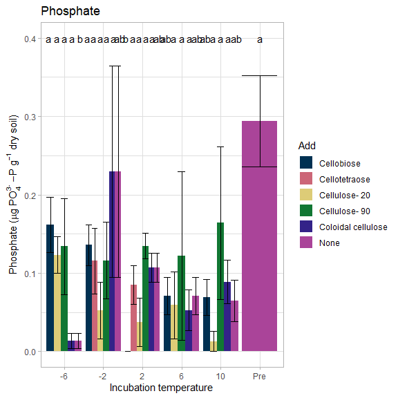

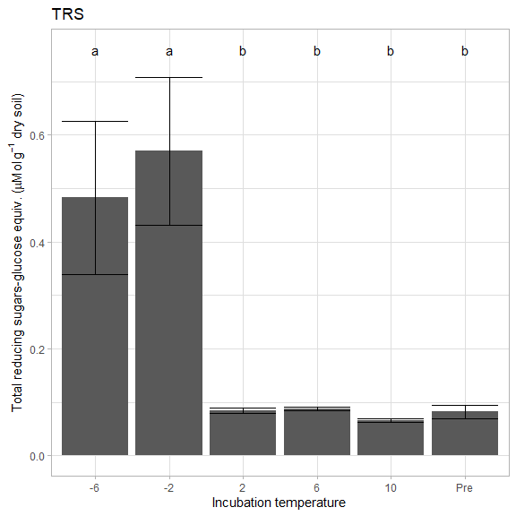

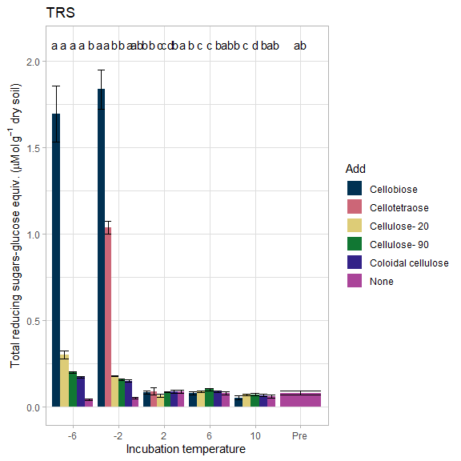

## Microbial biomass

**click to open**

Soil K2SO4 extracts and fumigated K2SO4 extracts were utilized to measure microbial biomass in the soils at the end of the incubation.

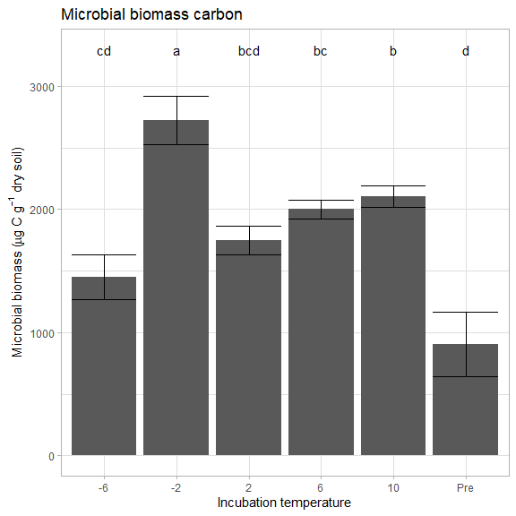

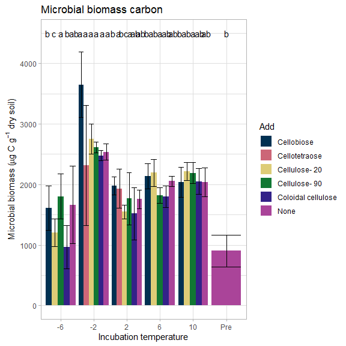

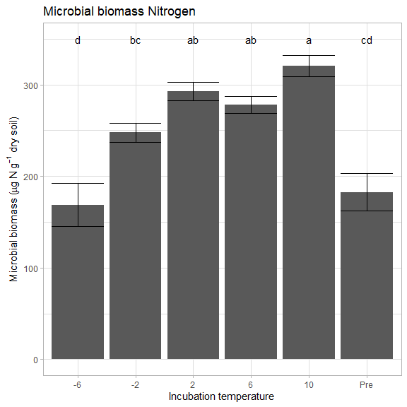

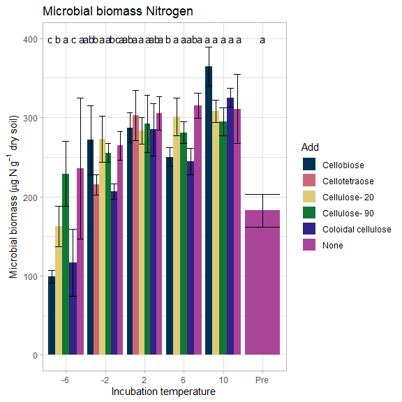

## Enzyme data

**click to open**

### Cellulases and hemicellulases

**click to open**

Cellulases and hemicellulase activity. This includes several downstream enzymes as well as upstream endo enzymes.

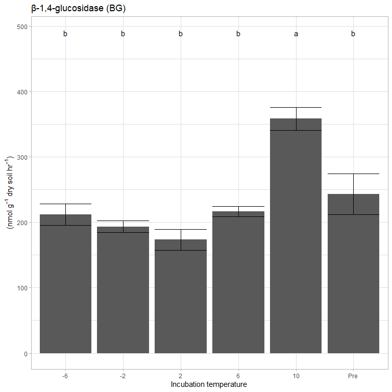

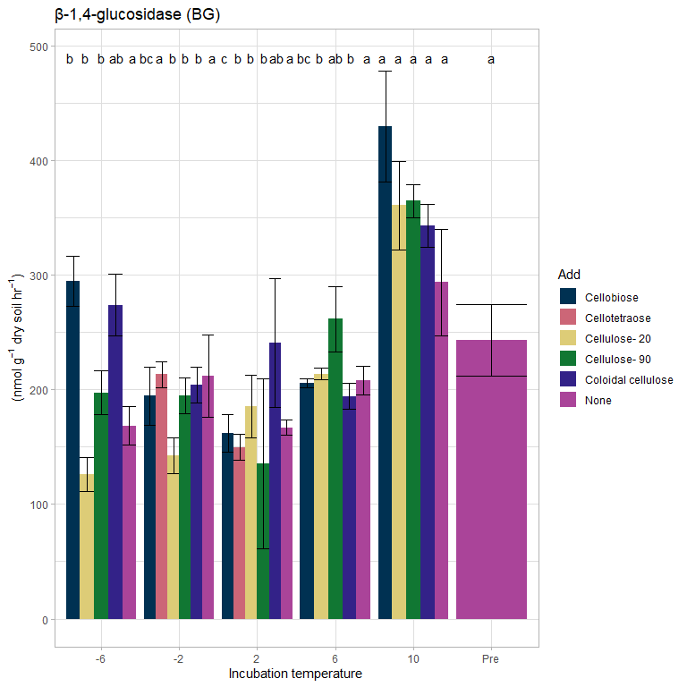

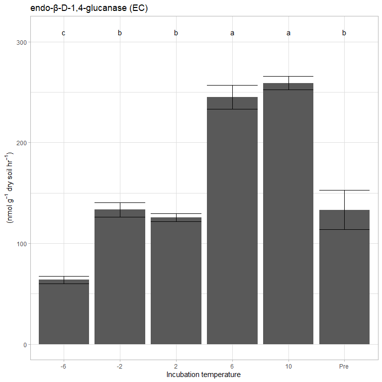

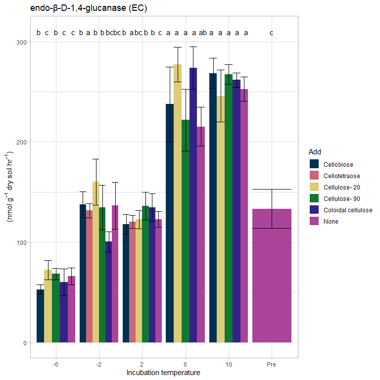

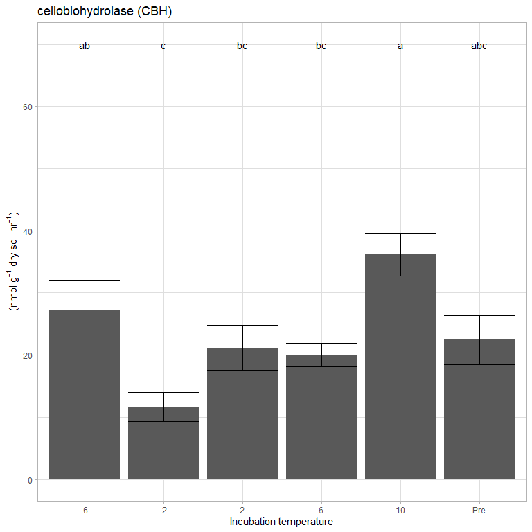

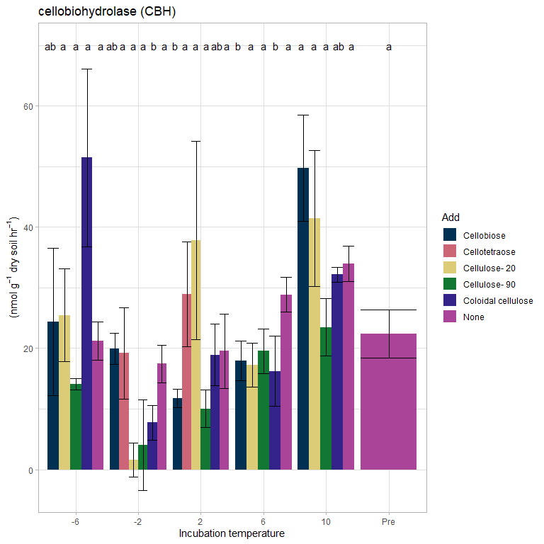

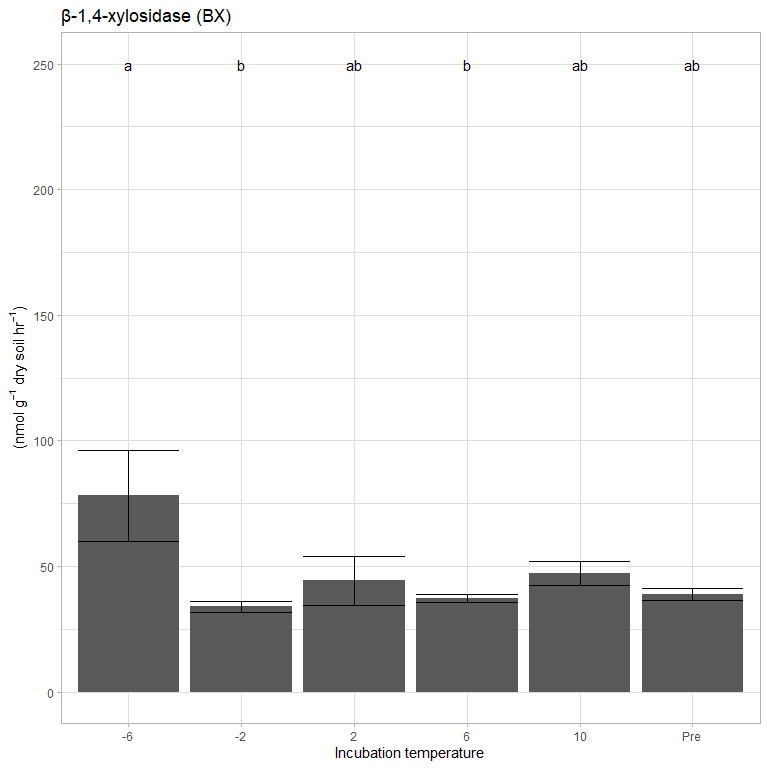

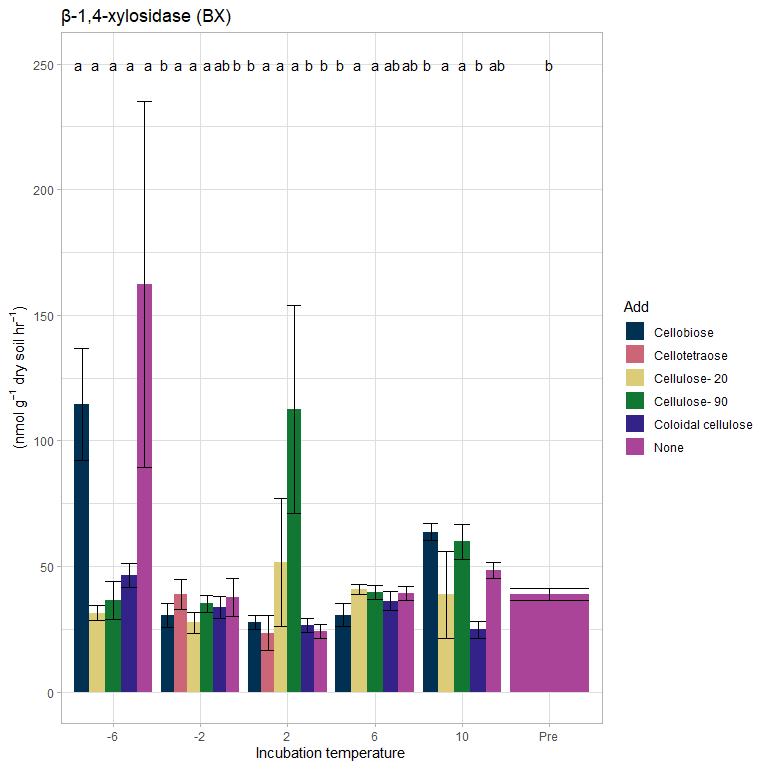

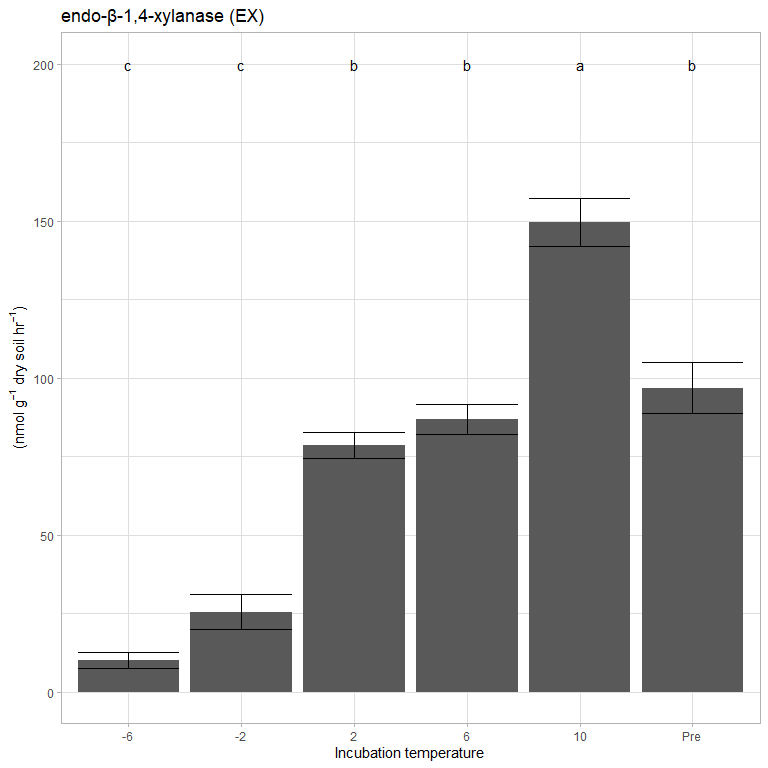

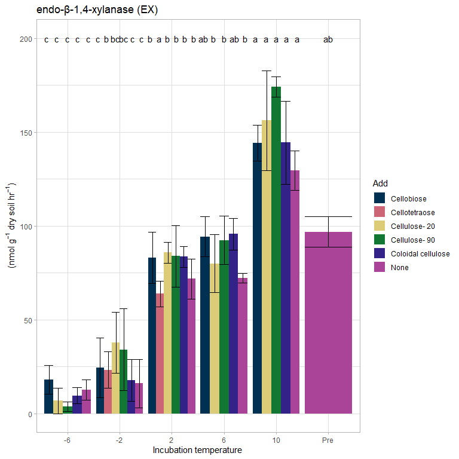

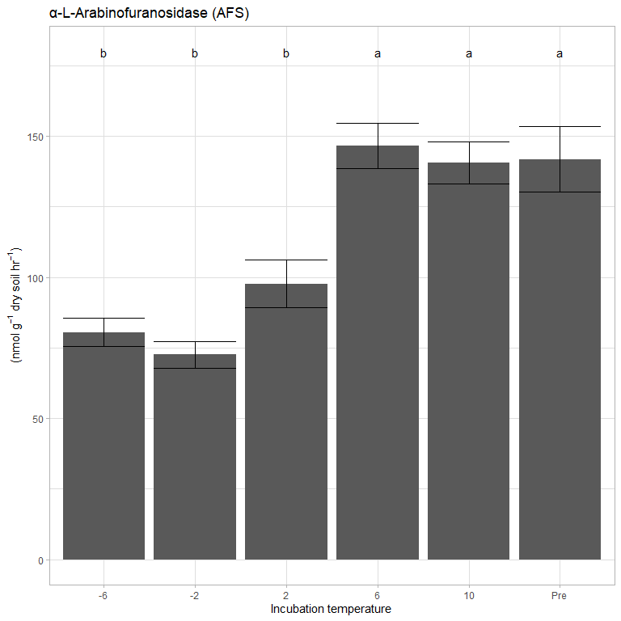

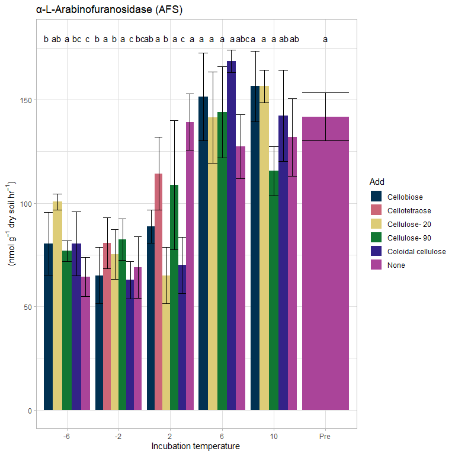

[5 more figures not shown]

### Nutrient and oxidative enzymes

**click to open**

Nutrient (nitrogen and phosphorus) acquiring enzyme activity

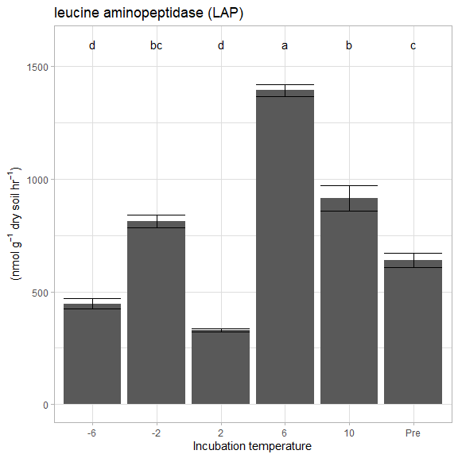

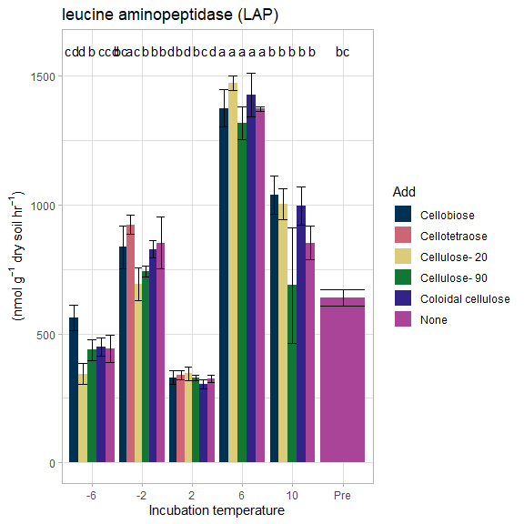

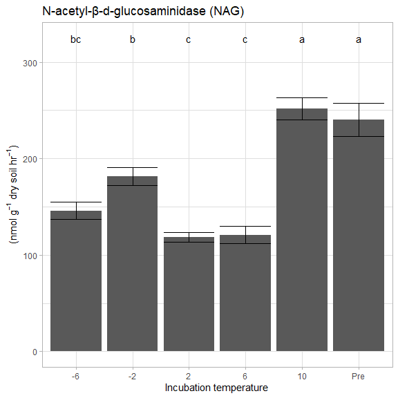

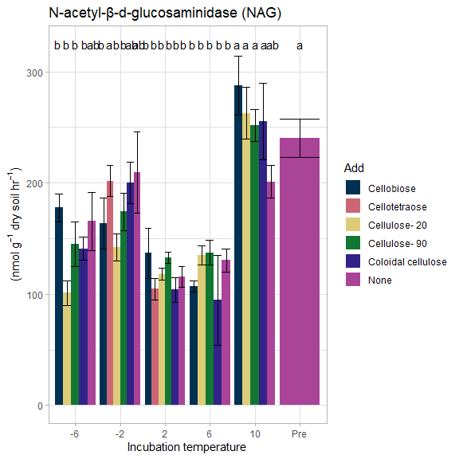

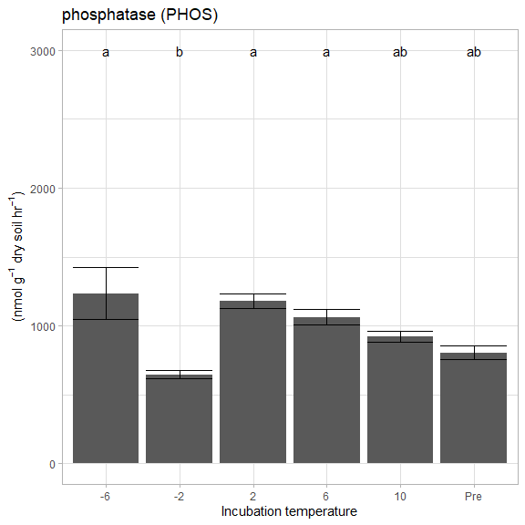

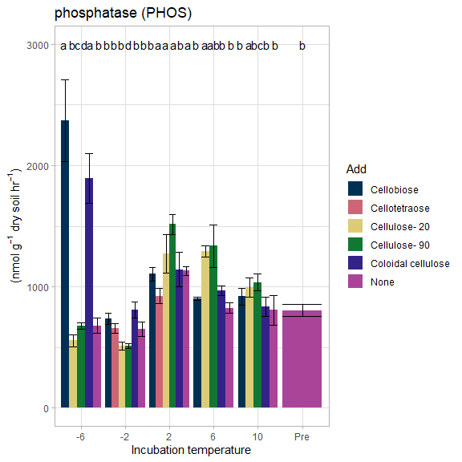

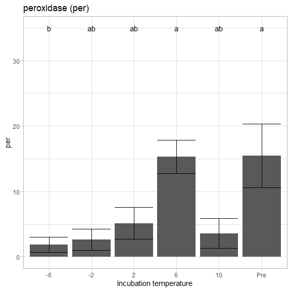

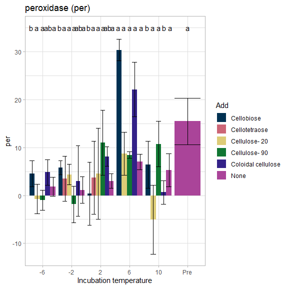

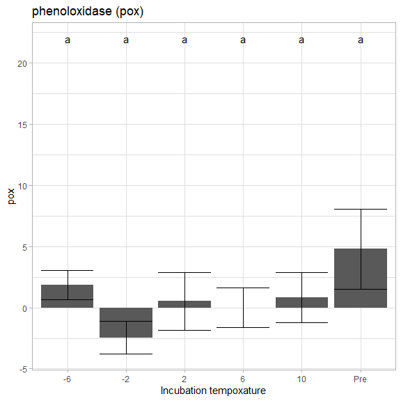

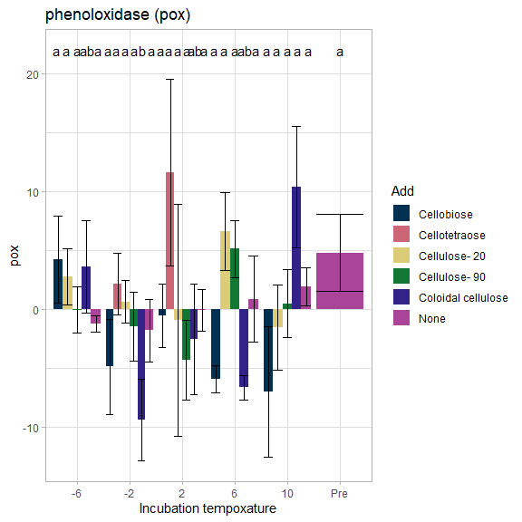

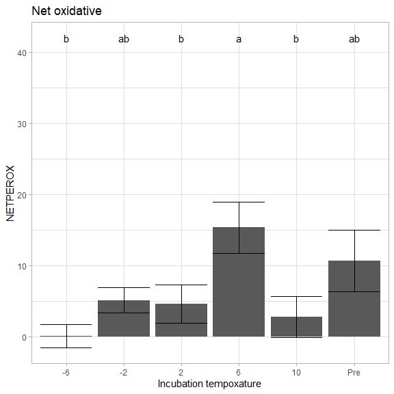

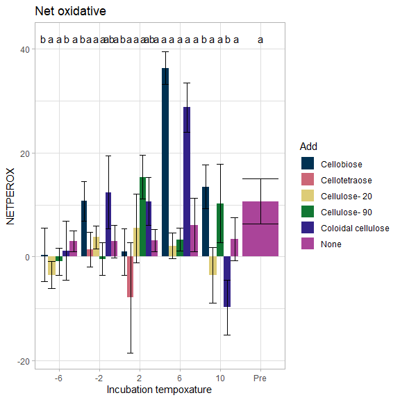

### Enzyme metrics

**click to open**

several calculated metrics

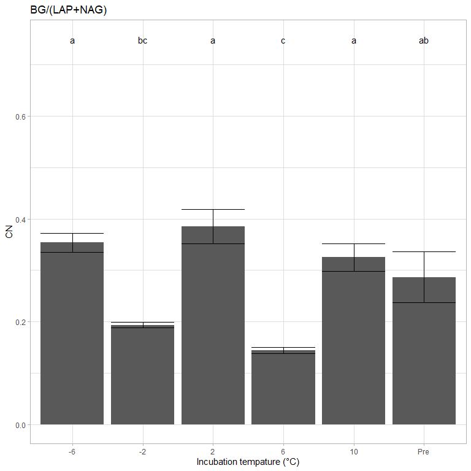

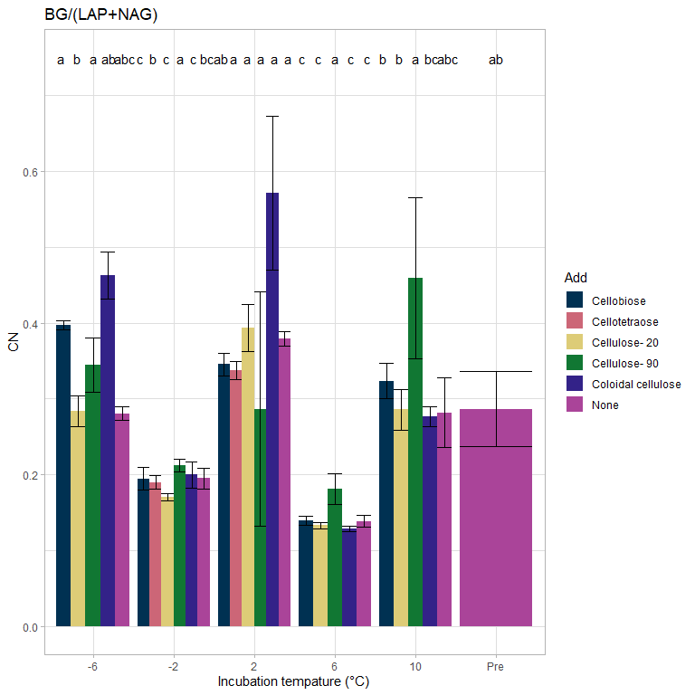

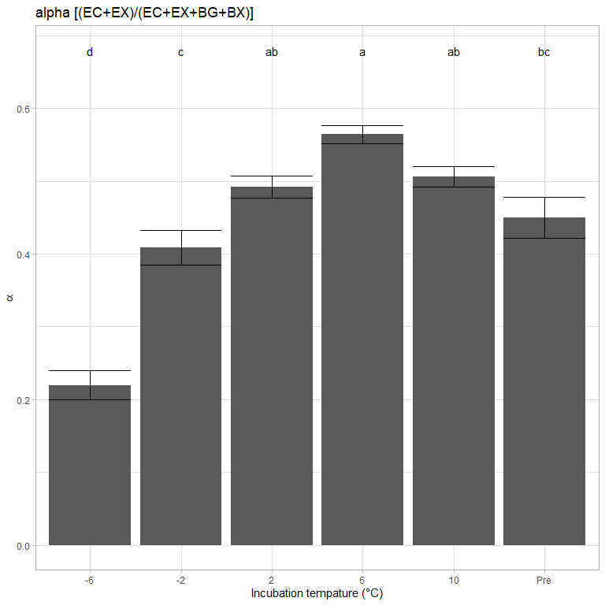

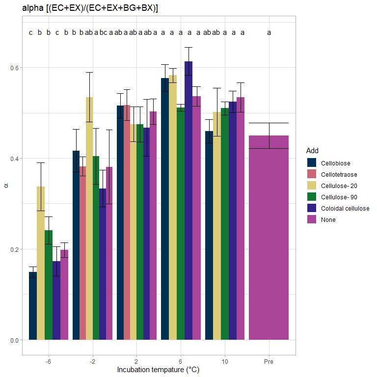

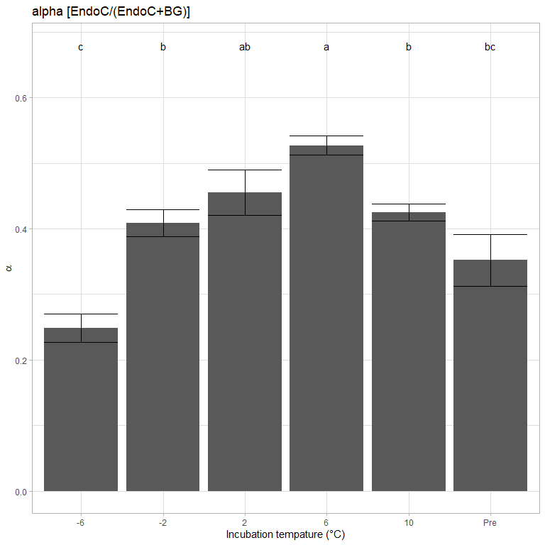

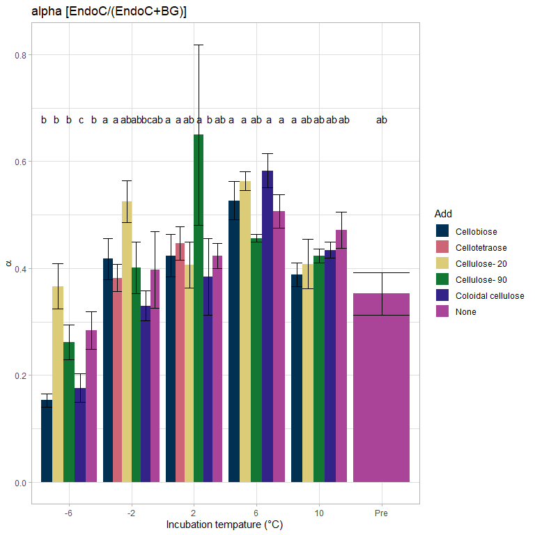

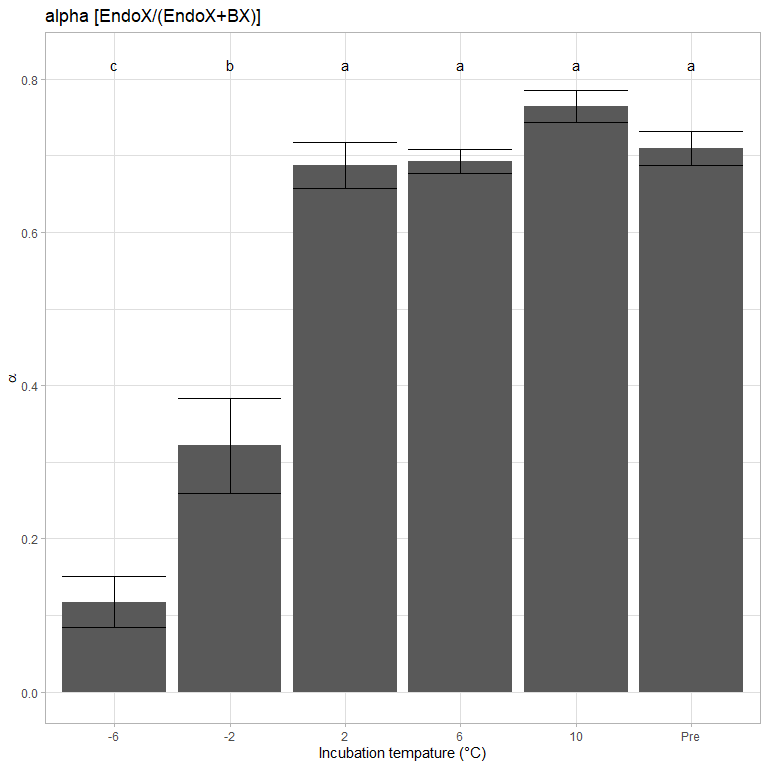

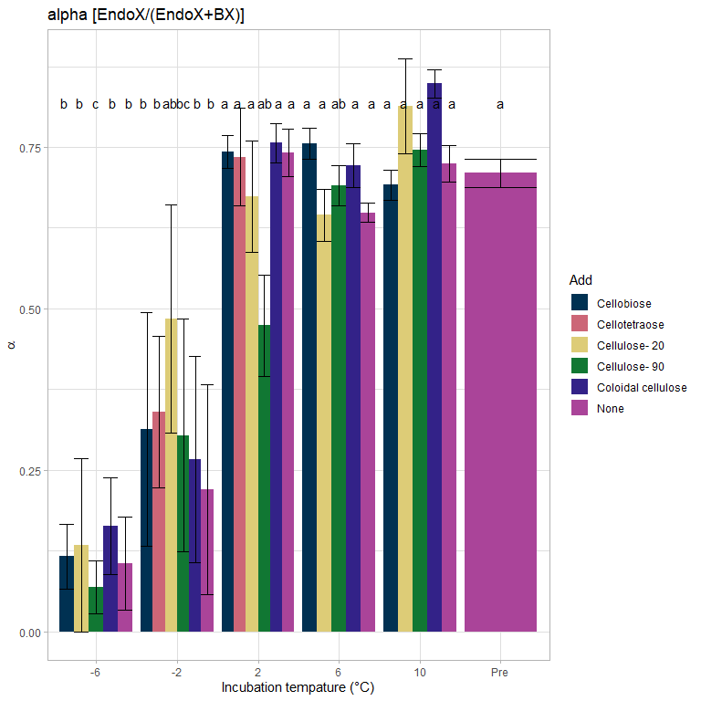

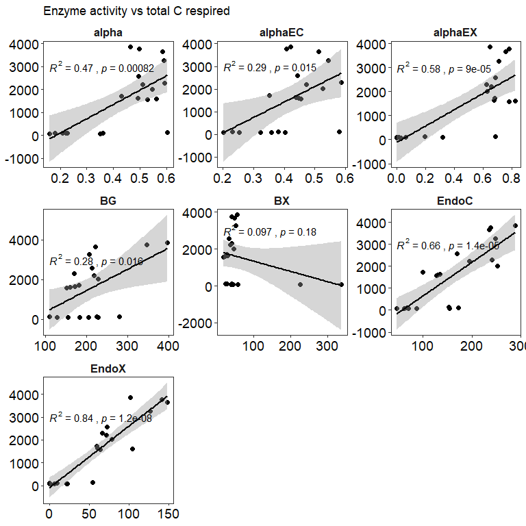

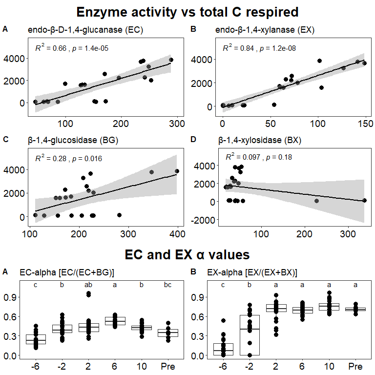

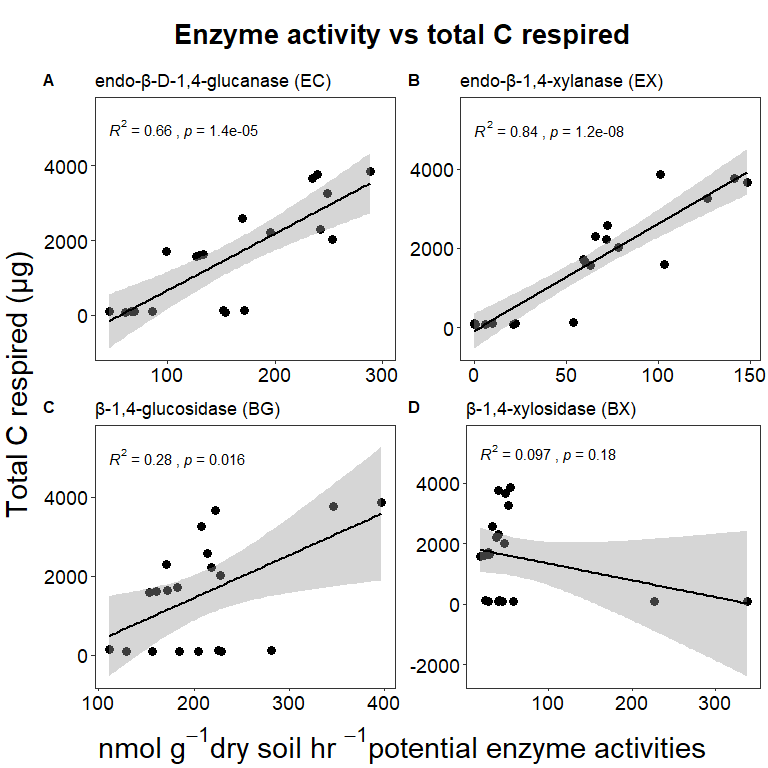

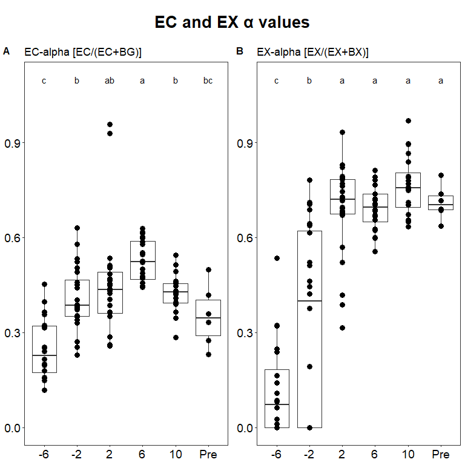

[3 more figures not shown]

## Estimated historic soil temperatures

**click to open**

Soil temperature estimates were constructed by correlating several years of soil measurements to air temperatures from Kotzebue AK. Then using this relationship soil temperature estimates were constructed from the years before soil measurements were taken.

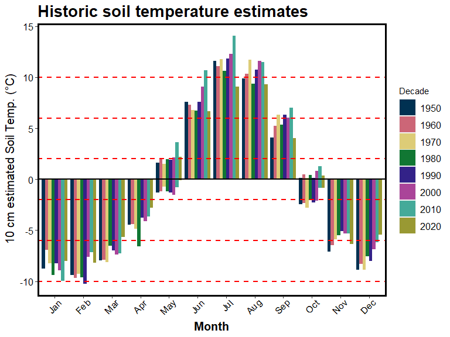

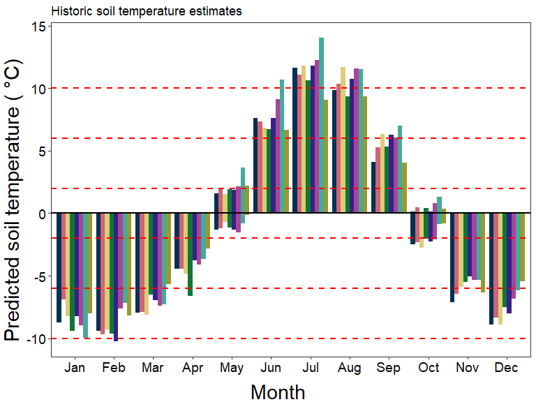

## Respiration rates divided by biomass plotted against Alpha

**click to open**

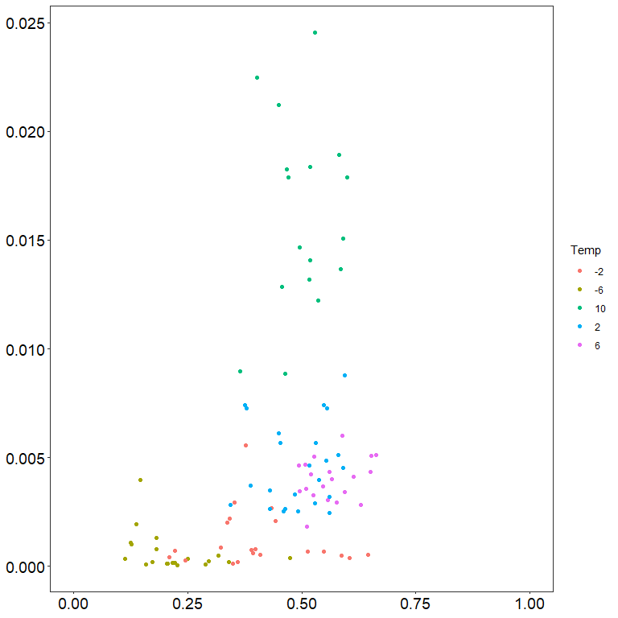

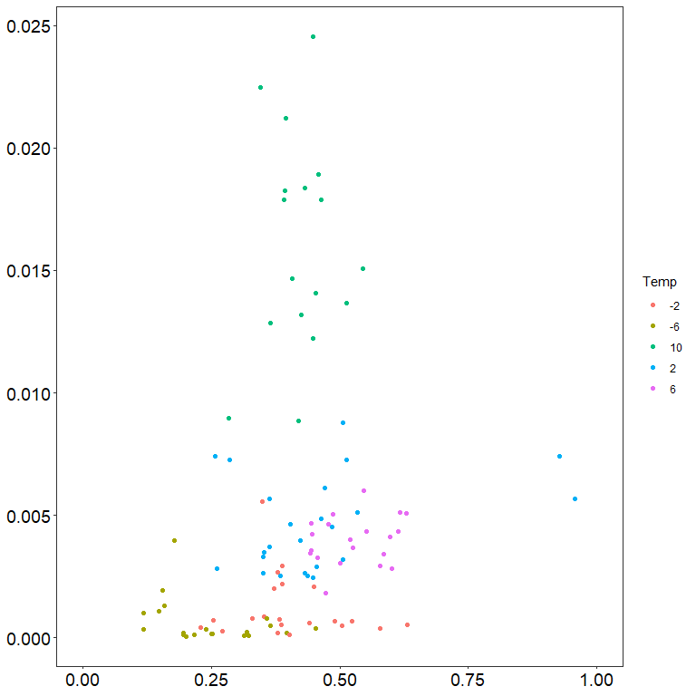

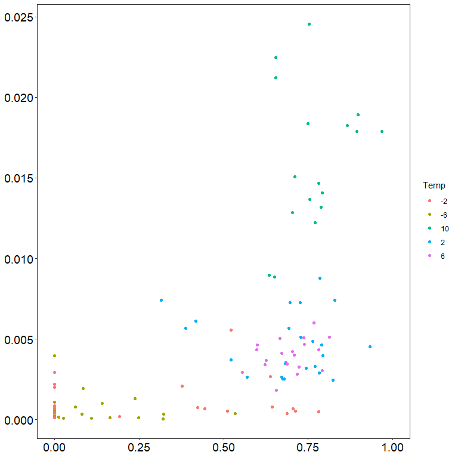

## Session Info

**Session Info**

Date run: 2025-01-23